# Project 1

Kevin Francis

10/12/2020

## Data Description

The data I choose describes the payment required when visiting a hospital in different regions. I want to know if the average admission deposit is the same for two different hospital regions. To gain some intuition about the data lets look at some summary statistics.

```r
data <- read.csv("test_data.csv")
hosp_add <- pull(data['Admission_Deposit'])
summ <- data %>%
  group_by(Hospital_region_code) %>%
  filter(!any(Hospital_region_code == "Z")) %>%
  summarise(mean = mean(Admission_Deposit), sd = sd(Admission_Deposit), median = median(Admission_Deposit), IQR = IQR(Admission_Deposit), mode = getmode(Admission_Deposit))
#Some data cleaning to make it easier to work with
X <- split.data.frame(data['Admission_Deposit'], data$Hospital_region_code)
groupx <- data.frame(unlist(X['X']))
groupx <- groupx %>% rename(Admission_Deposit = 'unlist.X..X...')
groupy <- data.frame(unlist(X['Y']))
groupy <- groupy %>% rename(Admission_Deposit = 'unlist.X..Y...')
```

Mean, Standard Deviation, Median, and IQR of Admission Deposit by Region

| Hospital_region_code | mean | sd | median | IQR | mode |
| --- | --- | --- | --- | --- | --- |
| X | 4803.230 | 1078.322 | 4670 | 1208.0 | 4465 |
| Y | 4848.334 | 1059.875 | 4712 | 1219.5 | 4273 |

Now lets look at some plots of the data. I like to start with distribution plots. These will show the shape of the data, any skewness, and in this case if the two data sets have similar distributions. Following that is a boxplot. This will help visualize the range of the data, median, IQR, and outliers.

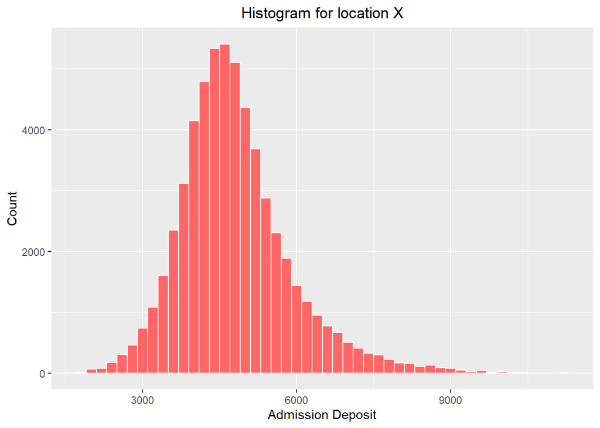

```r
ggplot(groupx, aes(x=Admission_Deposit)) +
  geom_histogram(binwidth = 200, color="white", fill="#FF6666") +
  ggtitle("Histogram for location X") + xlab("Admission Deposit") +
  ylab("Count") + theme(plot.title = element_text(hjust = 0.5))
```

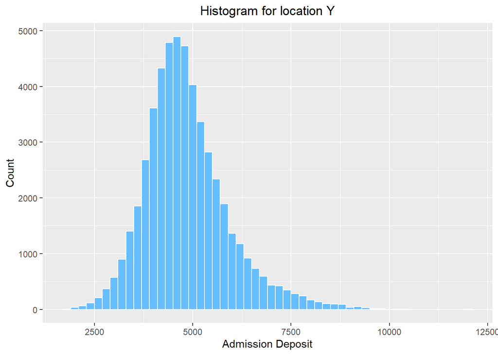

```r
ggplot(groupy, aes(x=Admission_Deposit)) +
  geom_histogram(binwidth = 200, color="white", fill="#66BDFF") +
  ggtitle("Histogram for location Y") + xlab("Admission Deposit") +
  ylab("Count") + theme(plot.title = element_text(hjust = 0.5))
```

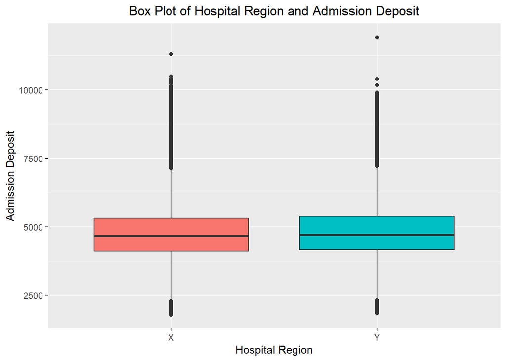

```r
data %>%
  group_by(Hospital_region_code) %>%
  filter(!any(Hospital_region_code == "Z")) %>%
  ggplot(aes(x=Hospital_region_code, y=Admission_Deposit, fill=Hospital_region_code)) + geom_boxplot(show.legend = FALSE) +
  ggtitle("Box Plot of Hospital Region and Admission Deposit") +
  ylab("Admission Deposit") + xlab("Hospital Region") +
  theme(plot.title = element_text(hjust = 0.5)) +
  scale_color_manual(values=c("#FF6666", "#66BDFF"))
```

It can be seen that the distributions are similar and the IQR of both data sets is not too different. This will help the assumption that the data models a normal distribution.

## Test

```r
ttest = t.test(groupx, groupy, alternative = "two.sided", mu = 0)
tscore = pt(ttest$statistic, ttest$parameter)
```

**Hypotheses**

$H_0: \mu_{x} = \mu_{y}$

$H_1: \mu_{x} \not= \mu_{y}$

**Test Statistic**

$t_0 = -6.984$

*p*-value

$p < 0.0001$

**Results**

Both of these conditions are met, so we reject the null hypothesis if using the test statistic or the p-value. Meaning the average admission deposit can not be assumed equal for hospitals located in regions X and Y.

## Follow-on Analysis

Seeing the t and p values made me second guess my test choice, so I did some more analysis of the underlying distributions. Here we look at the distributions of the two samples with respect to one another. This will help to visualize a shift between the two distribution, and any differences in overall shape.

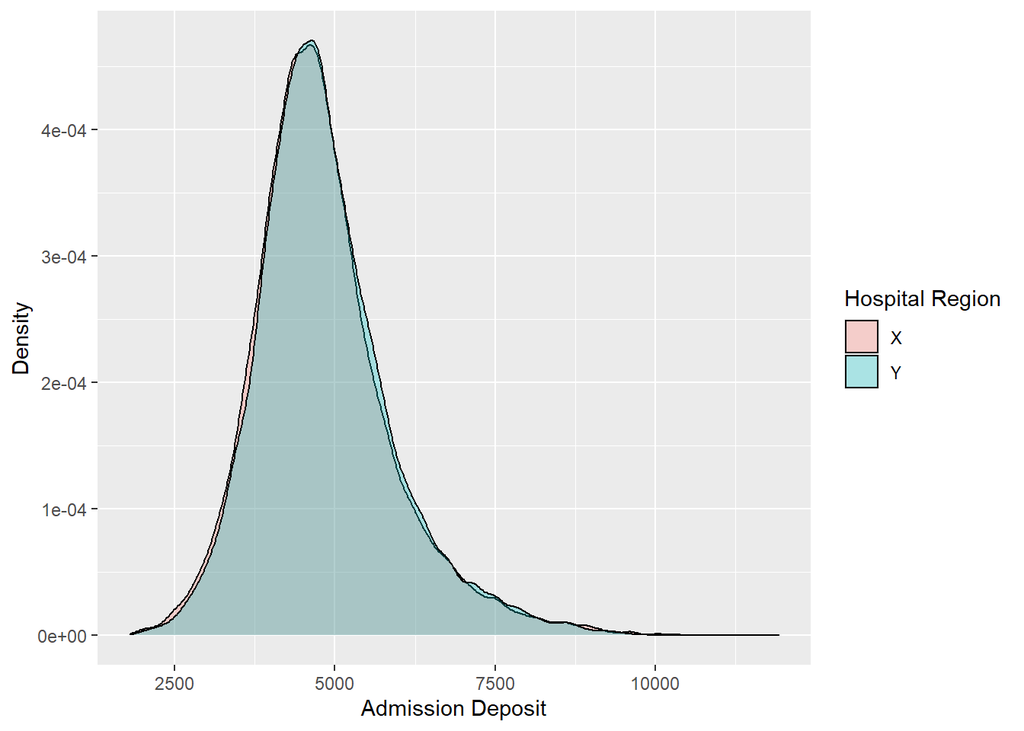

```r
data %>%
  group_by(Hospital_region_code) %>%
  filter(!any(Hospital_region_code == "Z")) %>%
  ggplot(aes(x = Admission_Deposit, fill = Hospital_region_code)) +
  geom_density(alpha=.3) + ylab("Density") + xlab("Admission Deposit") +
  labs(fill = "Hospital Region")
```

Now lets try and see just how normal the distributions are. Below are quantile-quantile, or Q-Q plots. If the data is from a normal distribution then the points should form a linear line. It can be seen that the two samples start to leave the normal line near the right side, this agrees with the longer right tails of the distributions. Due to the large size of the data sets I do not think this should have a big impact on the results.

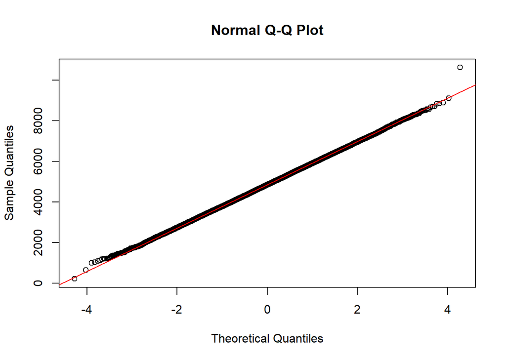

```r
norm <- rnorm(52279, summ$mean[2], summ$sd[2])
qqnorm(norm)
qqline(norm, col="red")
```

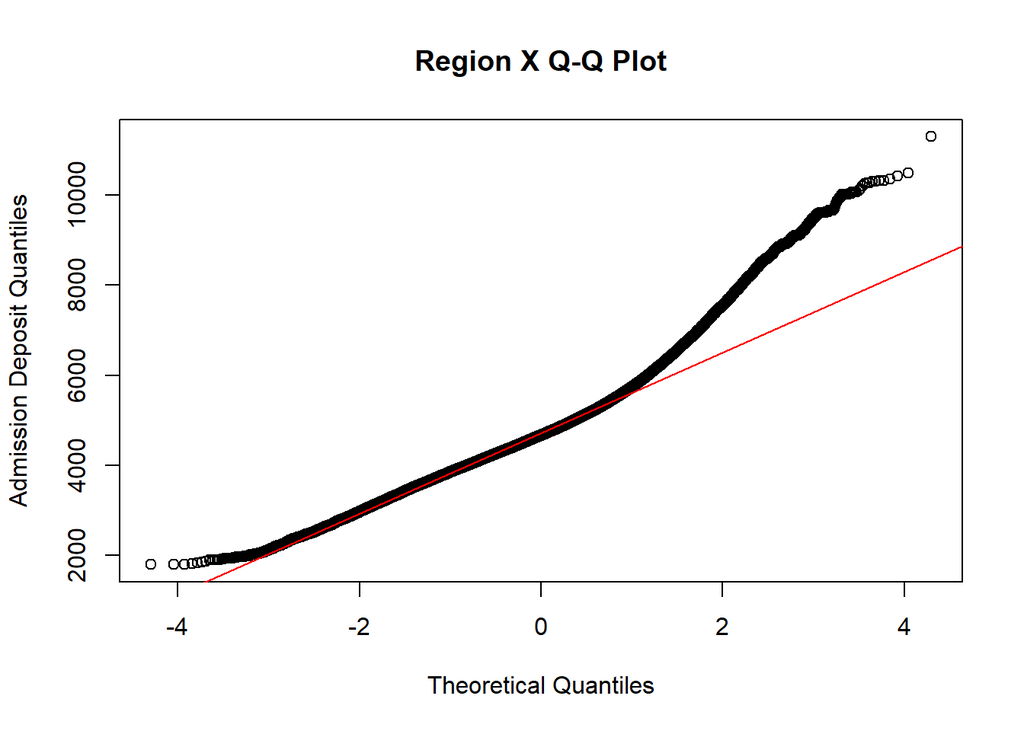

```r
qqnorm(groupx$Admission_Deposit, main = "Region X Q-Q Plot", ylab = "Admission Deposit Quantiles")
qqline(groupx$Admission_Deposit, col="red")
```

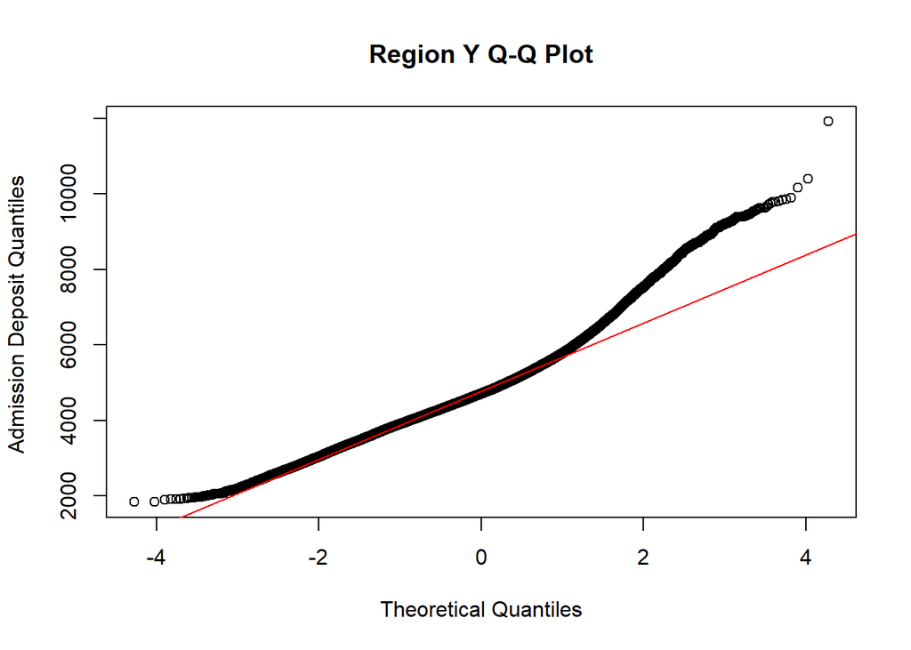

```r
qqnorm(groupy$Admission_Deposit, main = "Region Y Q-Q Plot", ylab = "Admission Deposit Quantiles ")
qqline(groupy$Admission_Deposit, col="red")
```